# Evidencia 2 | Proyecto integrador

Ernesto Miranda

2022-05-06

# Video parte 1

https://youtu.be/q_kW9PCZdMA

Utilización de las librerías:

```r
library(Biostrings)
library(seqinr)
library(adegenet)
library(ape)
library(ggtree)
library(DECIPHER)
library(viridis)
library(colormap)
library(ggmsa)
```

Primero recopilaré los códigos de acceso para las especies a estudiar. El código de acceso son los Locus en NCBI.

```r
speciesLocus <- c(humano = "MT093631", murcielago = "MN996532", pangolin = "MT084071",
                  pato = "JF705860", faisan = "MK423876",
                  erizo = "MK907287", civeta = "AY572038", civeta_palmeras = "AY613948",
                  paguma_larvata = "AY515512", rhinolophus = "KY417150", perro = "ON248600",
                  porcino = "KX981440", gorrión = "NC_016992",
                  beaudette = "AJ311317", bovino = "NC_003045", murino = "NC_001846",
                  gorila = "OL752443", gastrointeritis = "KX499468", mareca = "NC_016995",
                  ojo_blanco = "JQ065044")
if(!file.exists("virus_sequences.fasta")){
  virus.seq = read.GenBank(speciesLocus)
  write.dna(virus.seq,
            "virus_sequences.fasta",
            format = "fasta",
            nbcol = 5,
            colsep = ""
  )
  rm(virus.seq)
}
```

Después se hace el cálculo de la longitud de cada secuencia. En este punto no están alineadas.

```r
not_aligned <- readDNAStringSet("virus_sequences.fasta")
lapply(not_aligned, length)
```

```
## $MT093631
## [1] 29860
##
## $MN996532
## [1] 29855
##
## $MT084071
## [1] 27213
##
## $JF705860
## [1] 27673
##
## $MK423876
## [1] 27655
##
## $MK907287
## [1] 29951
##
## $AY572038
## [1] 29683
##
## $AY613948
## [1] 29730
##
## $AY515512
## [1] 29731
##
## $KY417150
## [1] 30311
##
## $ON248600
## [1] 29816
##
## $KX981440
## [1] 28124
##
## $NC_016992
## [1] 26083
##
## $AJ311317
## [1] 27635
##
## $NC_003045
## [1] 31028
##
## $NC_001846
## [1] 31357
##
## $OL752443
## [1] 29717
##
## $KX499468
## [1] 28614
##
## $NC_016995
## [1] 26227
##
## $JQ065044
## [1] 26041
```

Es momento de crear la gráfica para comparar el número de bases de cada secuencia no alineada. Para fines prácticos, se utilizarán los nombres de las secuencias.

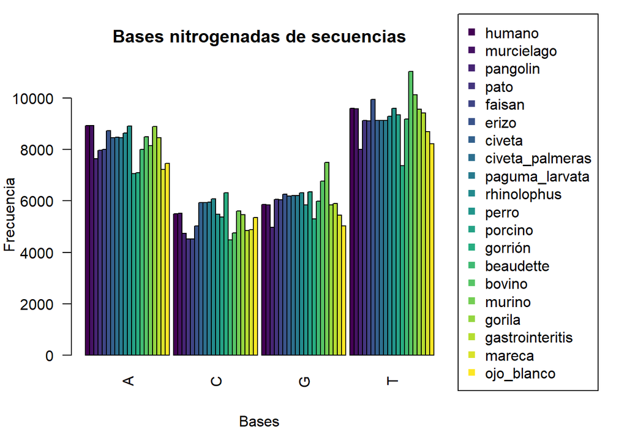

```r
bases <- lapply(not_aligned, tolower)
bases <- lapply(bases, s2c)
bases <- lapply(bases, count, wordsize = 1)
b <- c()
for(el in bases){
  b <- c(b, as.numeric(el))
}
B <- list(
  a = b[seq(from = 1, to = length(b), by = 4)],
  c = b[seq(from = 2, to = length(b), by = 4)],
  g = b[seq(from = 3, to = length(b), by = 4)],
  t = b[seq(from = 4, to = length(b), by = 4)]
)
par(mar = c(5,4,4,10), xpd = T)
colors = colormap(nshades = 20)
barplot(matrix(c(B$a, B$c, B$g, B$t), nrow = 20), beside = TRUE, col = colors, las =2, names.arg = c("A", "C", "G", "T"), ylab = "Frecuencia", xlab = "Bases", main = "Bases nitrogenadas de secuencias")
legend("topright",legend = names(speciesLocus) , col = colors,  pt.cex = 1, pch = 15 , cex = 1, inset = c(-0.4,-0.2))
```

```r
rm(B, bases, b, colors, el)
```

En la siguiente sección se agrega el análisis jerárquico

```r
not_aligned <- OrientNucleotides(not_aligned)
```

```
## ========================================================================================================================================================================================================
##
## Time difference of 0.23 secs
```

```r
seq_aligned <- AlignSeqs(not_aligned, processors = NULL)
```

```
## Determining distance matrix based on shared 11-mers:
## ================================================================================
##
## Time difference of 0.97 secs
##
## Clustering into groups by similarity:
## ================================================================================
##
## Time difference of 0.01 secs
##
## Aligning Sequences:
## ================================================================================
##
## Time difference of 55.42 secs
##
## Iteration 1 of 2:
##
## Determining distance matrix based on alignment:
## ================================================================================
##
## Time difference of 0.01 secs
##
## Reclustering into groups by similarity:
## ================================================================================
##
## Time difference of 0 secs
##
## Realigning Sequences:
## ================================================================================
##
## Time difference of 15.23 secs
##
## Iteration 2 of 2:
##
## Determining distance matrix based on alignment:
## ================================================================================
##
## Time difference of 0.01 secs
##
## Reclustering into groups by similarity:
## ================================================================================
##
## Time difference of 0 secs
##
## Realigning Sequences:
## ================================================================================
##
## Time difference of 0.01 secs
##
## Refining the alignment:
## ================================================================================
##
## Time difference of 49.82 secs
```

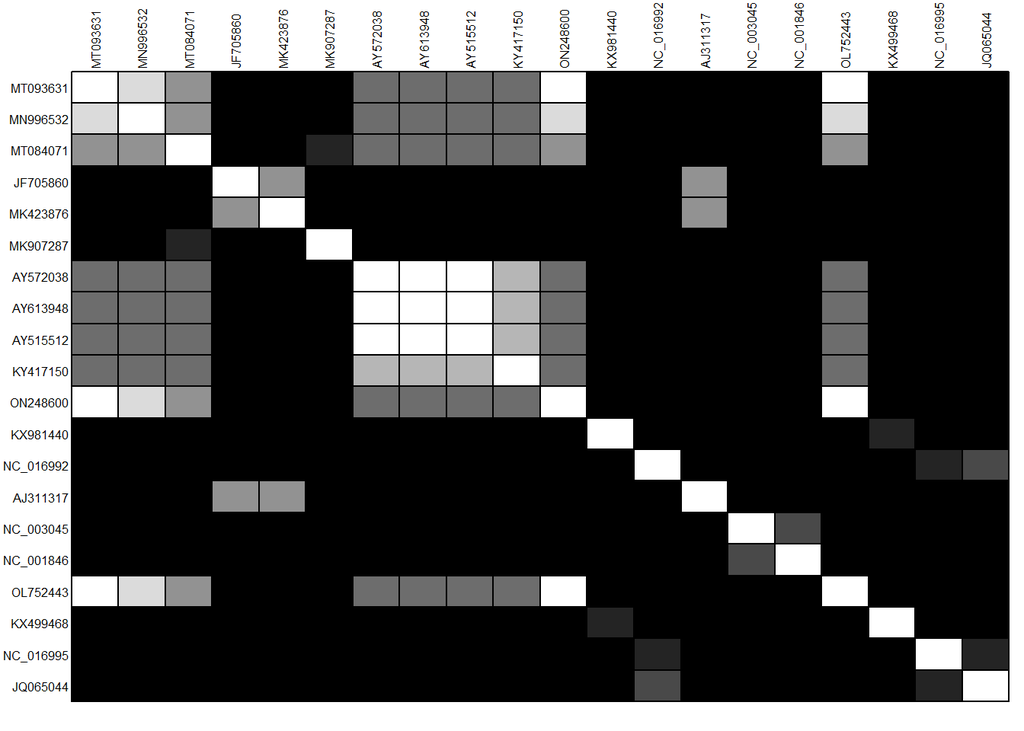

```r
# Resultado del alineamiento
BrowseSeqs(seq_aligned, highlight = 0)
writeXStringSet(seq_aligned, file="aligned_seq.fasta")
seq_aligned <- read.alignment("aligned_seq.fasta", format = "fasta")
matriz_distancia <- dist.alignment(seq_aligned, matrix = "similarity")
temp <- as.data.frame(as.matrix(matriz_distancia))
table.paint(temp, cleg=0, clabel.row=.5, clabel.col=.5) + scale_color_viridis()
```